# Trabalho de Estatística

Miguel Antônio Ribeiro e Silva - 4680

2022-08-07

## **Lendo a base de dados mtcars**

```r
mtcars
```

```
##                      mpg cyl  disp  hp drat    wt  qsec vs am gear carb
## Mazda RX4           21.0   6 160.0 110 3.90 2.620 16.46  0  1    4    4
## Mazda RX4 Wag       21.0   6 160.0 110 3.90 2.875 17.02  0  1    4    4
## Datsun 710          22.8   4 108.0  93 3.85 2.320 18.61  1  1    4    1
## Hornet 4 Drive      21.4   6 258.0 110 3.08 3.215 19.44  1  0    3    1
## Hornet Sportabout   18.7   8 360.0 175 3.15 3.440 17.02  0  0    3    2
## Valiant             18.1   6 225.0 105 2.76 3.460 20.22  1  0    3    1
## Duster 360          14.3   8 360.0 245 3.21 3.570 15.84  0  0    3    4
## Merc 240D           24.4   4 146.7  62 3.69 3.190 20.00  1  0    4    2
## Merc 230            22.8   4 140.8  95 3.92 3.150 22.90  1  0    4    2
## Merc 280            19.2   6 167.6 123 3.92 3.440 18.30  1  0    4    4
## Merc 280C           17.8   6 167.6 123 3.92 3.440 18.90  1  0    4    4
## Merc 450SE          16.4   8 275.8 180 3.07 4.070 17.40  0  0    3    3
## Merc 450SL          17.3   8 275.8 180 3.07 3.730 17.60  0  0    3    3
## Merc 450SLC         15.2   8 275.8 180 3.07 3.780 18.00  0  0    3    3
## Cadillac Fleetwood  10.4   8 472.0 205 2.93 5.250 17.98  0  0    3    4
## Lincoln Continental 10.4   8 460.0 215 3.00 5.424 17.82  0  0    3    4
## Chrysler Imperial   14.7   8 440.0 230 3.23 5.345 17.42  0  0    3    4
## Fiat 128            32.4   4  78.7  66 4.08 2.200 19.47  1  1    4    1
## Honda Civic         30.4   4  75.7  52 4.93 1.615 18.52  1  1    4    2
## Toyota Corolla      33.9   4  71.1  65 4.22 1.835 19.90  1  1    4    1
## Toyota Corona       21.5   4 120.1  97 3.70 2.465 20.01  1  0    3    1
## Dodge Challenger    15.5   8 318.0 150 2.76 3.520 16.87  0  0    3    2
## AMC Javelin         15.2   8 304.0 150 3.15 3.435 17.30  0  0    3    2
## Camaro Z28          13.3   8 350.0 245 3.73 3.840 15.41  0  0    3    4
## Pontiac Firebird    19.2   8 400.0 175 3.08 3.845 17.05  0  0    3    2
## Fiat X1-9           27.3   4  79.0  66 4.08 1.935 18.90  1  1    4    1
## Porsche 914-2       26.0   4 120.3  91 4.43 2.140 16.70  0  1    5    2
## Lotus Europa        30.4   4  95.1 113 3.77 1.513 16.90  1  1    5    2
## Ford Pantera L      15.8   8 351.0 264 4.22 3.170 14.50  0  1    5    4
## Ferrari Dino        19.7   6 145.0 175 3.62 2.770 15.50  0  1    5    6
## Maserati Bora       15.0   8 301.0 335 3.54 3.570 14.60  0  1    5    8
## Volvo 142E          21.4   4 121.0 109 4.11 2.780 18.60  1  1    4    2
```

```r
base <- data.frame(mtcars)
head(base)
```

```
##                    mpg cyl disp  hp drat    wt  qsec vs am gear carb
## Mazda RX4         21.0   6  160 110 3.90 2.620 16.46  0  1    4    4
## Mazda RX4 Wag     21.0   6  160 110 3.90 2.875 17.02  0  1    4    4
## Datsun 710        22.8   4  108  93 3.85 2.320 18.61  1  1    4    1
## Hornet 4 Drive    21.4   6  258 110 3.08 3.215 19.44  1  0    3    1
## Hornet Sportabout 18.7   8  360 175 3.15 3.440 17.02  0  0    3    2
## Valiant           18.1   6  225 105 2.76 3.460 20.22  1  0    3    1
```

## **Variáveis e tipos**

**mpg**: milhas/(US) galão - Quantitativa

**cyl**: número de cilindros - Qualitativa

**disp**: deslocamento - Quantitativa

**hp**: potência bruta - Quantitativa

**drat**: relação do eixo traseiro - Quantitativa

**wt**: peso (1000 libras) - Quantitativa

**qsec**: tempo de 1/4 de milha - Quantitativa

**vs**: motor (0 = em forma de V, 1 = reto) - Qualitativa

**am**: transmissão (0 = automática, 1 = manual) - Qualitativa

**gear**: número de marchas para frente - Qualitativa

**carb**: número de carburadores - Qualitativa

```r
base$cyl <- as.factor(base$cyl)
base$am <- as.factor(base$am)
base$gear <- as.factor(base$gear)
base$carb <- as.factor(base$carb)
str(base)
```

```
## 'data.frame':    32 obs. of  11 variables:
##  $ mpg : num  21 21 22.8 21.4 18.7 18.1 14.3 24.4 22.8 19.2 ...
##  $ cyl : Factor w/ 3 levels "4","6","8": 2 2 1 2 3 2 3 1 1 2 ...
##  $ disp: num  160 160 108 258 360 ...
##  $ hp  : num  110 110 93 110 175 105 245 62 95 123 ...
##  $ drat: num  3.9 3.9 3.85 3.08 3.15 2.76 3.21 3.69 3.92 3.92 ...
##  $ wt  : num  2.62 2.88 2.32 3.21 3.44 ...
##  $ qsec: num  16.5 17 18.6 19.4 17 ...
##  $ vs  : num  0 0 1 1 0 1 0 1 1 1 ...
##  $ am  : Factor w/ 2 levels "0","1": 2 2 2 1 1 1 1 1 1 1 ...
##  $ gear: Factor w/ 3 levels "3","4","5": 2 2 2 1 1 1 1 2 2 2 ...
##  $ carb: Factor w/ 6 levels "1","2","3","4",..: 4 4 1 1 2 1 4 2 2 4 ...
```

## **Descritivas de Quantitativas**

### mpg

```r
descritivampg <- data.frame(
  "Variável" = "mpg",
  "Média" = mean(base$mpg),
  "Variância" = var(base$mpg),
  "Mínimo" = min(base$mpg),
  "Q1" = quantile(base$mpg, 0.25),
  "Mediana" = median(base$mpg),
  "Q3" = quantile(base$mpg, 0.75),
  "Máximo" = max(base$mpg)

  )
descritivampg
```

```
##     Variável    Média Variância Mínimo     Q1 Mediana   Q3 Máximo
## 25%      mpg 20.09062   36.3241   10.4 15.425    19.2 22.8   33.9
```

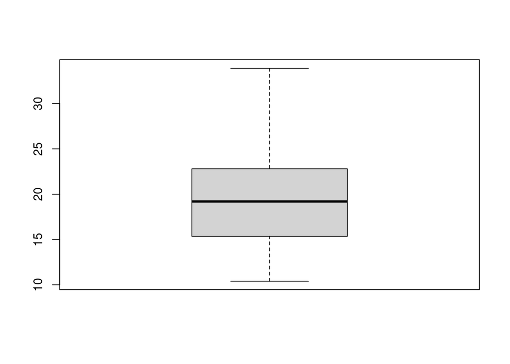

```r
boxplot(base$mpg)
```

### disp

```r
descritivadisp <- data.frame(
  "Variável" = "disp",
  "Média" = mean(base$disp),
  "Variância" = var(base$disp),
  "Mínimo" = min(base$disp),
  "Q1" = quantile(base$disp, 0.25),
  "Mediana" = median(base$disp),
  "Q3" = quantile(base$disp, 0.75),
  "Máximo" = max(base$disp)

  )
descritivadisp
```

```
##     Variável    Média Variância Mínimo      Q1 Mediana  Q3 Máximo
## 25%     disp 230.7219   15360.8   71.1 120.825   196.3 326    472
```

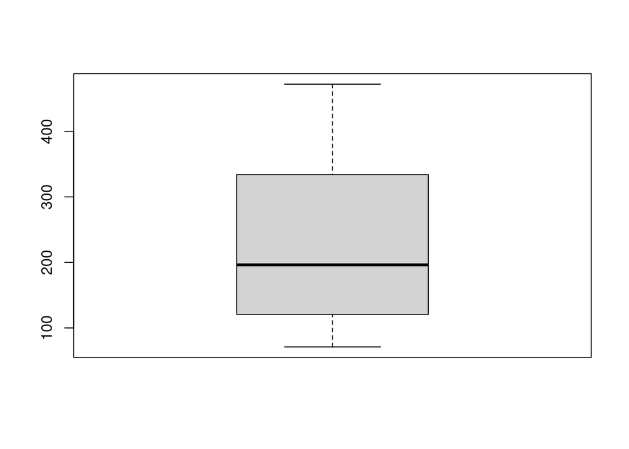

```r
boxplot(base$disp)
```

### hp

```r
descritivahp <- data.frame(
  "Variável" = "hp",
  "Média" = mean(base$hp),
  "Variância" = var(base$hp),
  "Mínimo" = min(base$hp),
  "Q1" = quantile(base$hp, 0.25),
  "Mediana" = median(base$hp),
  "Q3" = quantile(base$hp, 0.75),
  "Máximo" = max(base$hp)

  )
descritivahp
```

```
##     Variável    Média Variância Mínimo   Q1 Mediana  Q3 Máximo
## 25%       hp 146.6875  4700.867     52 96.5     123 180    335
```

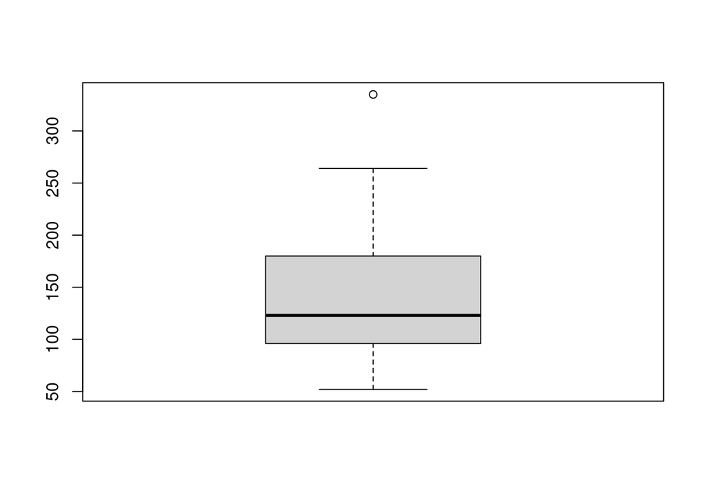

```r
boxplot(base$hp)
```

### drat

```r
descritivadrat <- data.frame(
  "Variável" = "drat",
  "Média" = mean(base$drat),
  "Variância" = var(base$drat),
  "Mínimo" = min(base$drat),
  "Q1" = quantile(base$drat, 0.25),
  "Mediana" = median(base$drat),
  "Q3" = quantile(base$drat, 0.75),
  "Máximo" = max(base$drat)

  )
descritivadrat
```

```
##     Variável    Média Variância Mínimo   Q1 Mediana   Q3 Máximo
## 25%     drat 3.596563 0.2858814   2.76 3.08   3.695 3.92   4.93
```

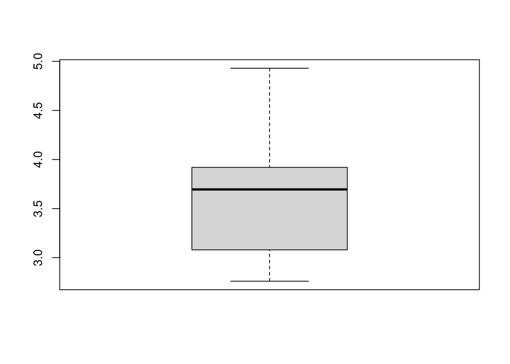

```r
boxplot(base$drat)
```

### wt

```r
descritivawt <- data.frame(
  "Variável" = "wt",
  "Média" = mean(base$wt),
  "Variância" = var(base$wt),
  "Mínimo" = min(base$wt),
  "Q1" = quantile(base$wt, 0.25),
  "Mediana" = median(base$wt),
  "Q3" = quantile(base$wt, 0.75),
  "Máximo" = max(base$wt)

  )
descritivawt
```

```
##     Variável   Média Variância Mínimo      Q1 Mediana   Q3 Máximo
## 25%       wt 3.21725  0.957379  1.513 2.58125   3.325 3.61  5.424
```

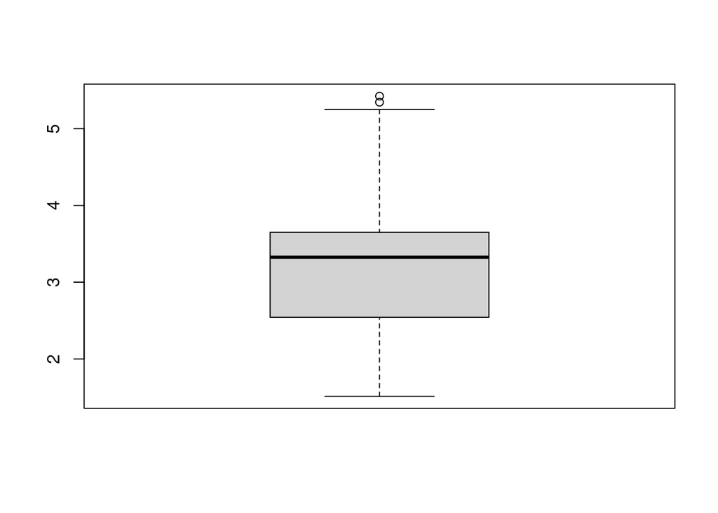

```r
boxplot(base$wt)
```

### qsec

```r
descritivaqsec <- data.frame(
  "Variável" = "qsec",
  "Média" = mean(base$qsec),
  "Variância" = var(base$qsec),
  "Mínimo" = min(base$qsec),
  "Q1" = quantile(base$qsec, 0.25),
  "Mediana" = median(base$qsec),
  "Q3" = quantile(base$qsec, 0.75),
  "Máximo" = max(base$qsec)

  )
descritivaqsec
```

```
##     Variável    Média Variância Mínimo      Q1 Mediana   Q3 Máximo
## 25%     qsec 17.84875  3.193166   14.5 16.8925   17.71 18.9   22.9
```

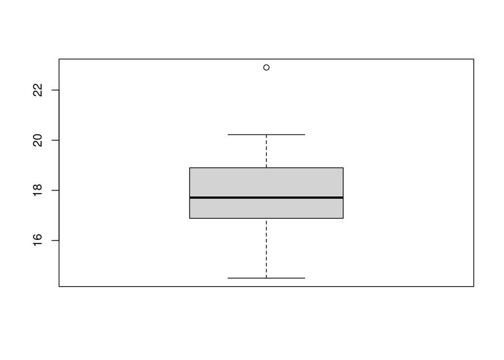

```r
boxplot(base$qsec)
```

### Tabela com todas

```r
descritivas <- rbind(descritivampg, descritivadisp, descritivahp, descritivadrat, descritivawt, descritivaqsec)
descritivas
```

```
##      Variável      Média    Variância Mínimo        Q1 Mediana     Q3  Máximo
## 25%       mpg  20.090625 3.632410e+01 10.400  15.42500  19.200  22.80  33.900
## 25%1     disp 230.721875 1.536080e+04 71.100 120.82500 196.300 326.00 472.000
## 25%2       hp 146.687500 4.700867e+03 52.000  96.50000 123.000 180.00 335.000
## 25%3     drat   3.596563 2.858814e-01  2.760   3.08000   3.695   3.92   4.930
## 25%4       wt   3.217250 9.573790e-01  1.513   2.58125   3.325   3.61   5.424
## 25%5     qsec  17.848750 3.193166e+00 14.500  16.89250  17.710  18.90  22.900
```

## **Descritivas de Qualitativas**

### cyl

```r
table(base$cyl)
```

```
##
##  4  6  8
## 11  7 14
```

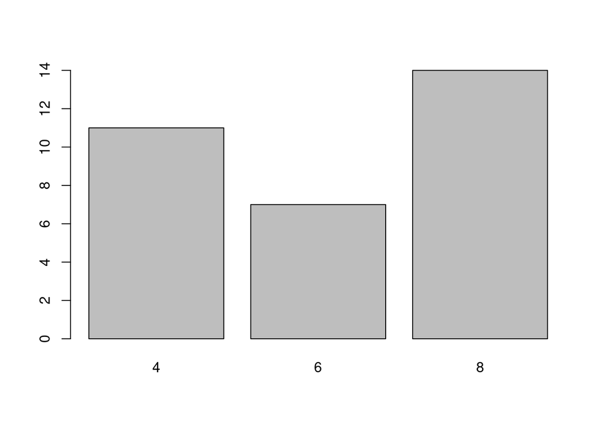

```r
plot(base$cyl)
```

### vs

```r
table(base$vs)
```

```
##
##  0  1
## 18 14
```

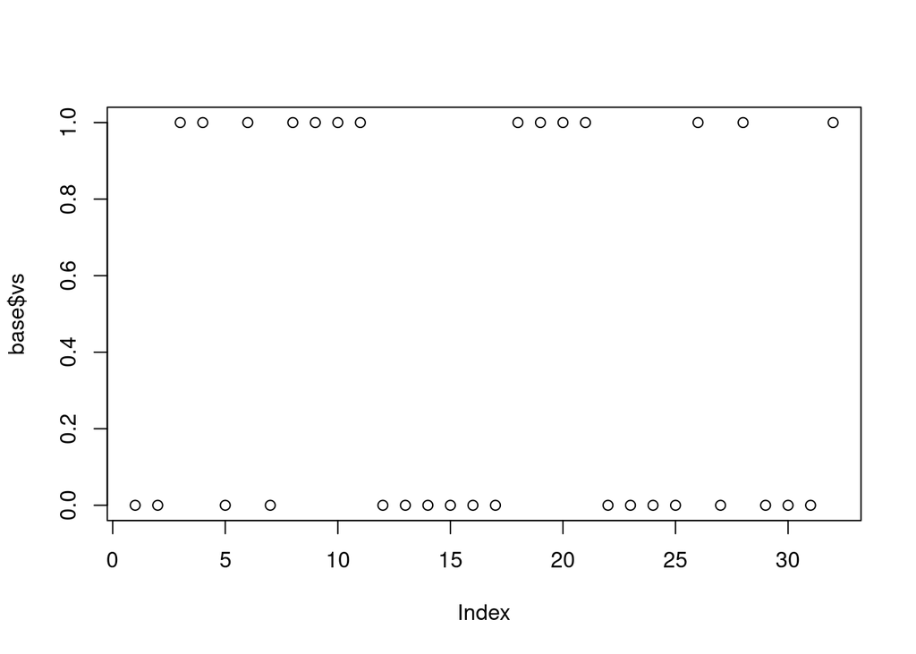

```r
plot(base$vs)
```

### am

```r
table(base$am)
```

```
##
##  0  1
## 19 13
```

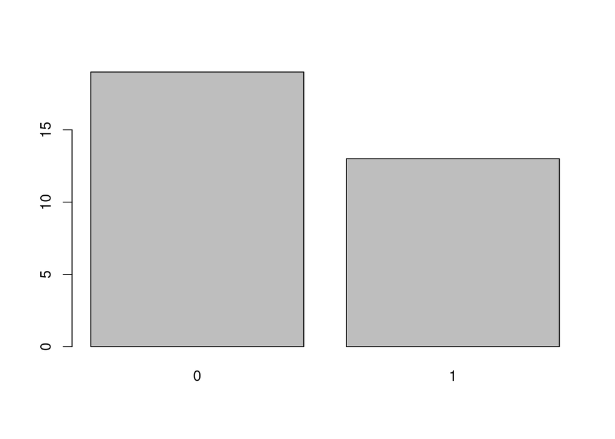

```r
plot(base$am)
```

### gear

```r
table(base$gear)
```

```
##
##  3  4  5
## 15 12  5
```

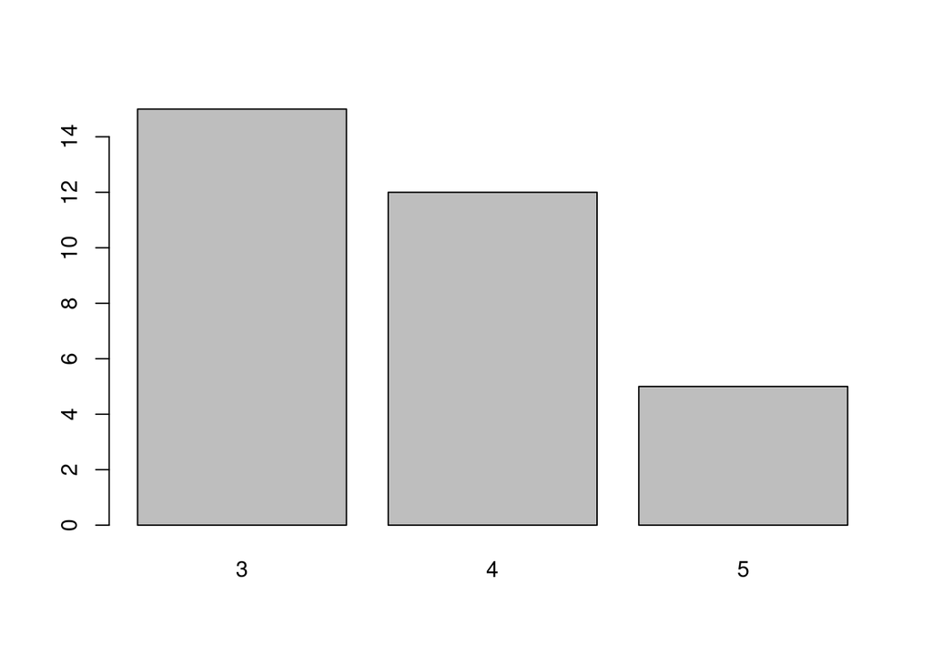

```r
plot(base$gear)
```

### carb

```r
table(base$carb)
```

```
##
##  1  2  3  4  6  8
##  7 10  3 10  1  1
```

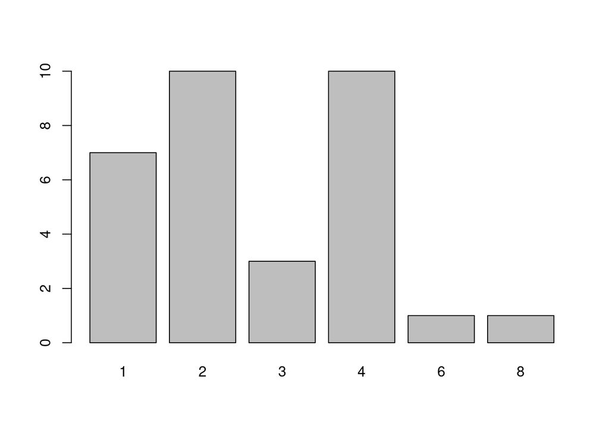

```r
plot(base$carb)
```

## **Descritiva Bivariada**

### mpg x am

```r
mpg0 <- base$mpg[base$am == "0"]
mpg1 <- base$mpg[base$am == "1"]
```

```r
descritiva_mpgxam <- data.frame(
  "Variável" = "mpg",
  "Grupo" = c("0 - automática", "1 - manual"),
  "Média" = c(mean(mpg0), mean(mpg1)),
  "Variância" = c(var(mpg0), var(mpg1)),
  "Mínimo" = c(min(mpg0), min(mpg1)),
  "Q1" = c(quantile(mpg0, 0.25), quantile(mpg1, 0.25)),
  "Mediana" = c(median(mpg0), median(mpg1)),
  "Q3" = c(quantile(mpg0, 0.75), quantile(mpg1, 0.75)),
  "Máximo" = c(max(mpg0), max(mpg1))
)
descritiva_mpgxam
```

```
##   Variável          Grupo    Média Variância Mínimo    Q1 Mediana   Q3 Máximo
## 1      mpg 0 - automática 17.14737  14.69930   10.4 14.95    17.3 19.2   24.4
## 2      mpg     1 - manual 24.39231  38.02577   15.0 21.00    22.8 30.4   33.9
```

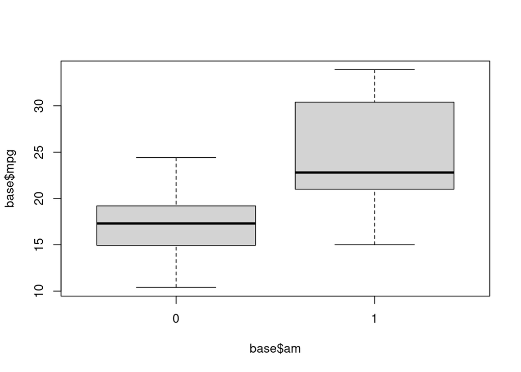

```r
boxplot(base$mpg ~ base$am)
```

### disp x am

```r
disp0 <- base$disp[base$am == "0"]
disp1 <- base$disp[base$am == "1"]
```

```r
descritiva_dispxam <- data.frame(
  "Variável" = "disp",
  "Grupo" = c("0 - automática", "1 - manual"),
  "Média" = c(mean(disp0), mean(disp1)),
  "Variância" = c(var(disp0), var(disp1)),
  "Mínimo" = c(min(disp0), min(disp1)),
  "Q1" = c(quantile(disp0, 0.25), quantile(disp1, 0.25)),
  "Mediana" = c(median(disp0), median(disp1)),
  "Q3" = c(quantile(disp0, 0.75), quantile(disp1, 0.75)),
  "Máximo" = c(max(disp0), max(disp1))
)
descritiva_dispxam
```

```
##   Variável          Grupo    Média Variância Mínimo    Q1 Mediana  Q3 Máximo
## 1     disp 0 - automática 290.3789 12137.792  120.1 196.3   275.8 360    472
## 2     disp     1 - manual 143.5308  7604.536   71.1  79.0   120.3 160    351
```

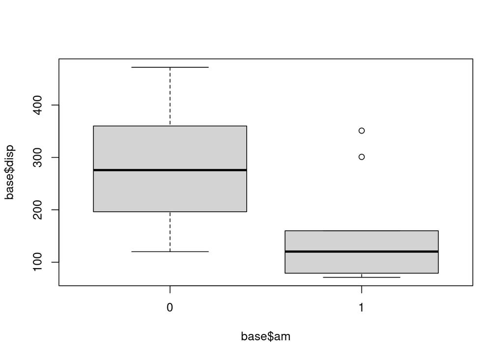

```r
boxplot(base$disp ~ base$am)
```

### hp x am

```r
hp0 <- base$hp[base$am == "0"]
hp1 <- base$hp[base$am == "1"]
```

```r
descritiva_hpxam <- data.frame(
  "Variável" = "hp",
  "Grupo" = c("0 - automática", "1 - manual"),
  "Média" = c(mean(hp0), mean(hp1)),
  "Variância" = c(var(hp0), var(hp1)),
  "Mínimo" = c(min(hp0), min(hp1)),
  "Q1" = c(quantile(hp0, 0.25), quantile(hp1, 0.25)),
  "Mediana" = c(median(hp0), median(hp1)),
  "Q3" = c(quantile(hp0, 0.75), quantile(hp1, 0.75)),
  "Máximo" = c(max(hp0), max(hp1))
)
descritiva_hpxam
```

```
##   Variável          Grupo    Média Variância Mínimo    Q1 Mediana    Q3 Máximo
## 1       hp 0 - automática 160.2632  2906.094     62 116.5     175 192.5    245
## 2       hp     1 - manual 126.8462  7066.474     52  66.0     109 113.0    335
```

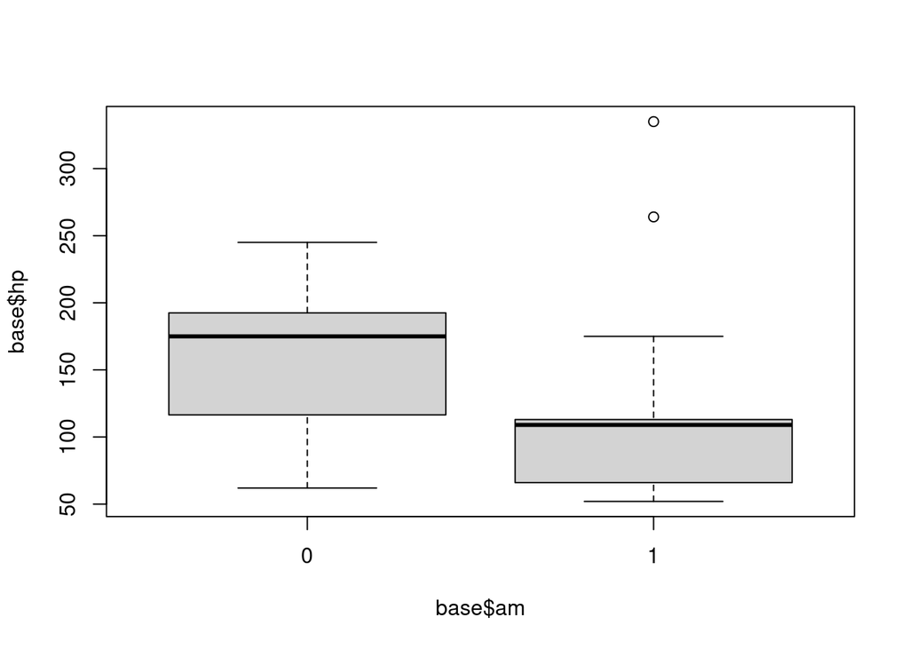

```r
boxplot(base$hp ~ base$am)
```

### drat x am

```r
drat0 <- base$drat[base$am == "0"]
drat1 <- base$drat[base$am == "1"]
```

```r
descritiva_dratxam <- data.frame(
  "Variável" = "drat",
  "Grupo" = c("0 - automática", "1 - manual"),
  "Média" = c(mean(drat0), mean(drat1)),
  "Variância" = c(var(drat0), var(drat1)),
  "Mínimo" = c(min(drat0), min(drat1)),
  "Q1" = c(quantile(drat0, 0.25), quantile(drat1, 0.25)),
  "Mediana" = c(median(drat0), median(drat1)),
  "Q3" = c(quantile(drat0, 0.75), quantile(drat1, 0.75)),
  "Máximo" = c(max(drat0), max(drat1))
)
descritiva_dratxam
```

```
##   Variável          Grupo    Média Variância Mínimo   Q1 Mediana    Q3 Máximo
## 1     drat 0 - automática 3.286316 0.1539023   2.76 3.07    3.15 3.695   3.92
## 2     drat     1 - manual 4.050000 0.1325333   3.54 3.85    4.08 4.220   4.93
```

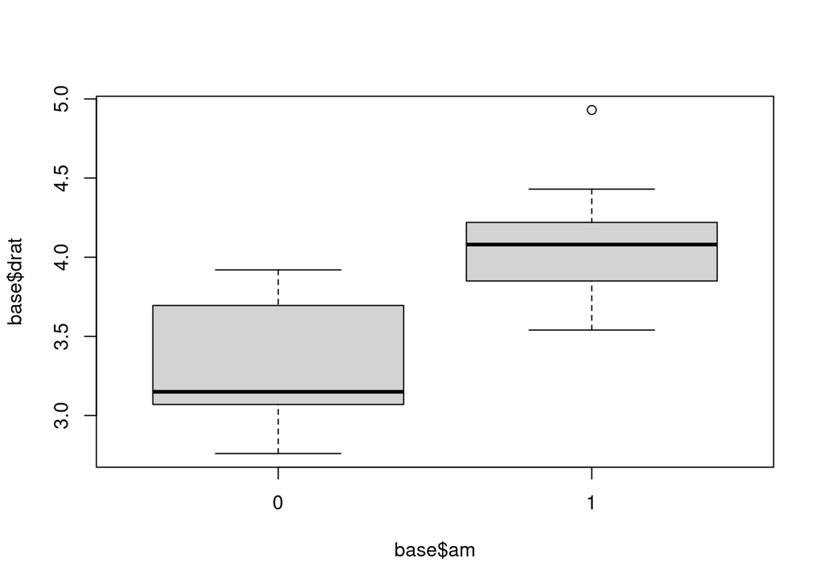

```r
boxplot(base$drat ~ base$am)
```

### wt x am

```r
wt0 <- base$wt[base$am == "0"]
wt1 <- base$wt[base$am == "1"]
```

```r
descritiva_wtxam <- data.frame(
  "Variável" = "wt",
  "Grupo" = c("0 - automática", "1 - manual"),
  "Média" = c(mean(wt0), mean(wt1)),
  "Variância" = c(var(wt0), var(wt1)),
  "Mínimo" = c(min(wt0), min(wt1)),
  "Q1" = c(quantile(wt0, 0.25), quantile(wt1, 0.25)),
  "Mediana" = c(median(wt0), median(wt1)),
  "Q3" = c(quantile(wt0, 0.75), quantile(wt1, 0.75)),
  "Máximo" = c(max(wt0), max(wt1))
)
descritiva_wtxam
```

```
##   Variável          Grupo    Média Variância Mínimo     Q1 Mediana     Q3
## 1       wt 0 - automática 3.768895 0.6043510  2.465 3.4375    3.52 3.8425
## 2       wt     1 - manual 2.411000 0.3806663  1.513 1.9350    2.32 2.7800
##   Máximo
## 1  5.424
## 2  3.570
```

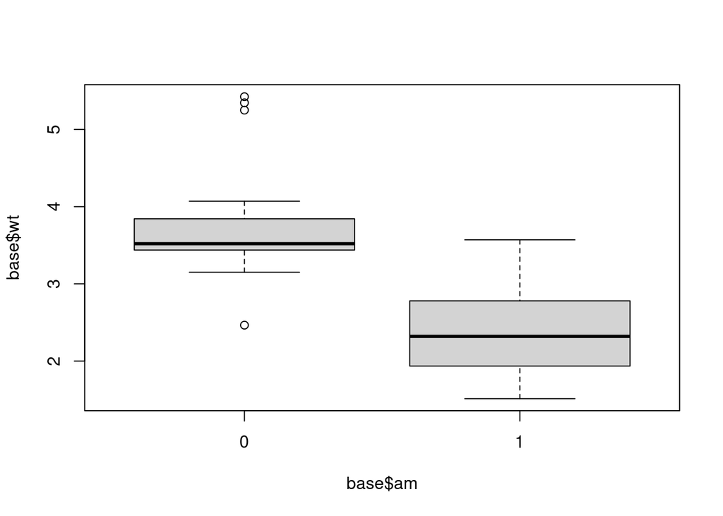

```r
boxplot(base$wt ~ base$am)
```

### qsec x am

```r
qsec0 <- base$qsec[base$am == "0"]
qsec1 <- base$qsec[base$am == "1"]
```

```r
descritiva_qsecxam <- data.frame(
  "Variável" = "qsec",
  "Grupo" = c("0 - automática", "1 - manual"),
  "Média" = c(mean(qsec0), mean(qsec1)),
  "Variância" = c(var(qsec0), var(qsec1)),
  "Mínimo" = c(min(qsec0), min(qsec1)),
  "Q1" = c(quantile(qsec0, 0.25), quantile(qsec1, 0.25)),
  "Mediana" = c(median(qsec0), median(qsec1)),
  "Q3" = c(quantile(qsec0, 0.75), quantile(qsec1, 0.75)),
  "Máximo" = c(max(mpg0), max(mpg1))
)
descritiva_qsecxam
```

[output not shown]

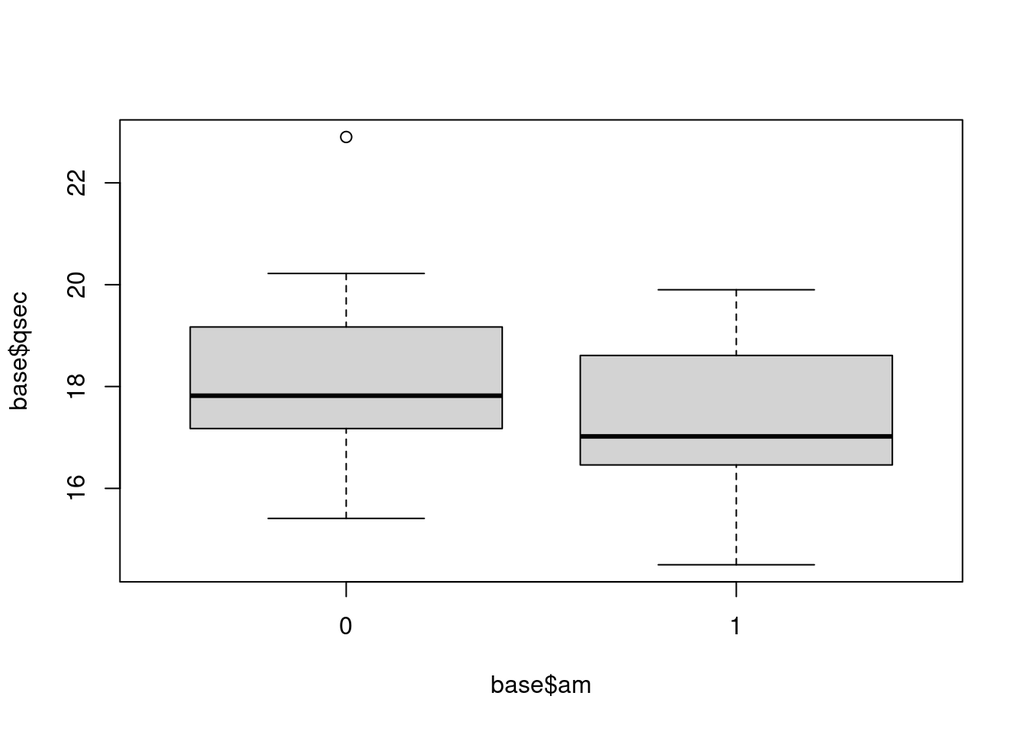

```r
boxplot(base$qsec ~ base$am)
```

## **Avaliando correlação**

### mpg e disp

```r
cor(base$mpg, base$disp)
```

```
## [1] -0.8475514
```

### mpg e hp

```r
cor(base$mpg, base$hp)
```

```
## [1] -0.7761684
```

A correlação entre as duas variáveis é negativa, ou seja, quanto maior a proporção milhas/galão, menor é a potência bruta.

### disp e hp

```r
cor(base$disp, base$hp )
```

```
## [1] 0.7909486
```

## **Teste de Hipóteses**

### Um colecionador de carros afirma que a média da potência bruta da sua coleção é de 150. Ele então disponibiliza uma amostra (mtcars) da sua coleção. Ele está mentindo?

H0: média da potência bruta == 150

```r
teste <- t.test(base$hp, mu=150)
teste
```

```
##
##  One Sample t-test
##
## data:  base$hp
## t = -0.2733, df = 31, p-value = 0.7864
## alternative hypothesis: true mean is not equal to 150
## 95 percent confidence interval:
##  121.9679 171.4071
## sample estimates:
## mean of x
##  146.6875
```

> Como p-valor é > que 0.05, a um nível de significância de 5%, não rejeita-se H0, ou seja, não há evidências suficientes para discordar da afirmação do colecionador.

```r
# install.packages("gginference")
```

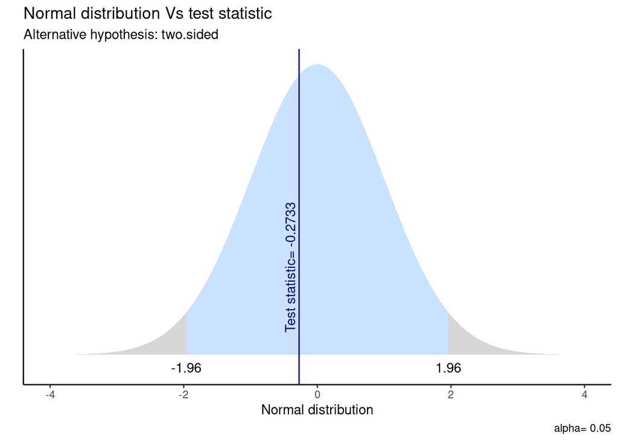

```r
gginference::ggttest(teste)
```

### A média das milhas por galão de carros com transmissão automatica é igual a carros com transmissão manual?

H0: media_mpg0 == media_mpg1

```r
teste <- t.test(mpg0, mpg1)
teste
```

```
##
##  Welch Two Sample t-test
##
## data:  mpg0 and mpg1
## t = -3.7671, df = 18.332, p-value = 0.001374
## alternative hypothesis: true difference in means is not equal to 0
## 95 percent confidence interval:
##  -11.280194  -3.209684
## sample estimates:
## mean of x mean of y
##  17.14737  24.39231
```

> A um nível de significância de 5%, rejeitamos H0, ou seja, as médias são diferentes.

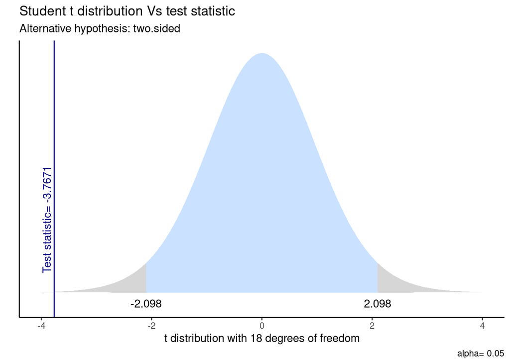

```r
gginference::ggttest(teste)
```

### A média do hp dos carros com 4 cilindros é igual a média do hp dos carros com 6 cilindros?

```r
hp4 <- base$hp[base$cyl == "4"]
hp6 <- base$hp[base$cyl == "6"]
```

H0: media_hp4 == media_hp6

```r
teste <- t.test(hp4, hp6)
teste
```

```
##
##  Welch Two Sample t-test
##
## data:  hp4 and hp6
## t = -3.5617, df = 11.486, p-value = 0.004176
## alternative hypothesis: true difference in means is not equal to 0
## 95 percent confidence interval:
##  -64.02500 -15.27371
## sample estimates:
## mean of x mean of y
##  82.63636 122.28571
```

> A um nível de significância de 5%, rejeitamos H0, ou seja, as médias são diferentes.

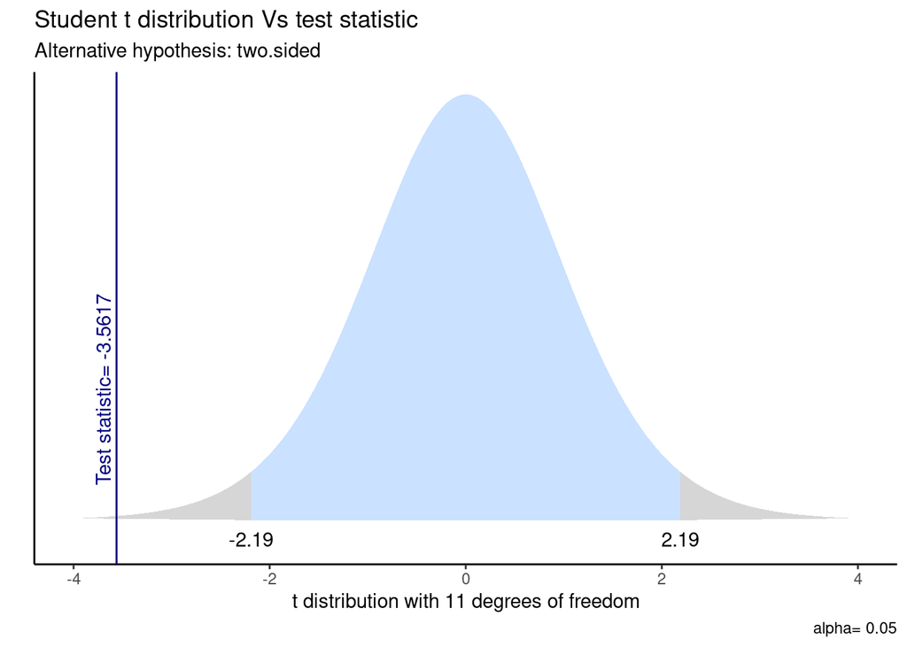

```r
gginference::ggttest(teste)
```

### A média do hp dos carros com 6 cilindros é igual a média do hp dos carros com 8 cilindros?

```r
hp8 = base$hp[base$cyl == "8"]
```

H0: media_hp6 == media_hp8

```r
teste <- t.test(hp6, hp8)
teste
```

```
##
##  Welch Two Sample t-test
##
## data:  hp6 and hp8
## t = -5.2933, df = 18.999, p-value = 4.148e-05
## alternative hypothesis: true difference in means is not equal to 0
## 95 percent confidence interval:
##  -121.30146  -52.55568
## sample estimates:
## mean of x mean of y
##  122.2857  209.2143
```

> A um nível de significância de 5%, rejeitamos H0, ou seja, as médias são diferentes.

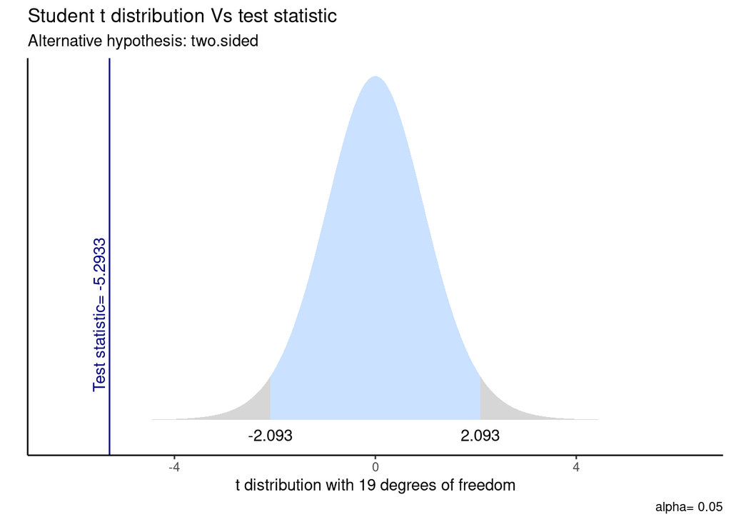

```r
gginference::ggttest(teste)
```

### A média do hp dos carros com 4 cilindros é igual a média do hp dos carros com 8 cilindros?

H0: media_hp4 == media_hp8

```r
teste <- t.test(hp4, hp8)
teste
```

```
##
##  Welch Two Sample t-test
##
## data:  hp4 and hp8
## t = -8.4299, df = 18.096, p-value = 1.108e-07
## alternative hypothesis: true difference in means is not equal to 0
## 95 percent confidence interval:
##  -158.11189  -95.04396
## sample estimates:
## mean of x mean of y
##  82.63636 209.21429
```

> A um nível de significância de 5%, rejeitamos H0, ou seja, as médias são diferentes.

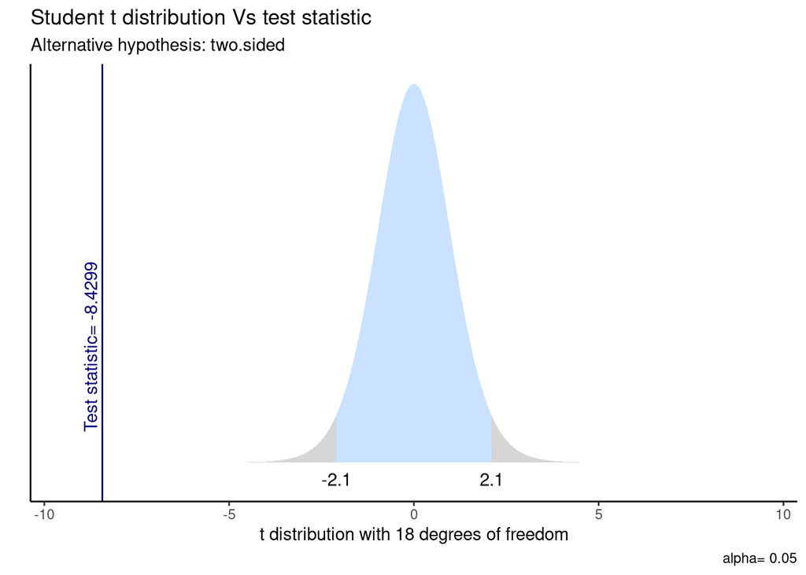

```r
gginference::ggttest(teste)
```